# Análise - PIM -PF

Jonatha Azevedo e Leonardo Filgueira

November 25, 2017

### Os dados

Utilizando o pacote `BETS` podemos obter esse dado atualizado em tempo real atráves da API do SIDRA.

```r
require(BETS)
dados = BETS.sidra.get(x = c(3653), from = c("200201"), to = c("201710"), territory = "brazil",variable = 3135, sections = c(129316), cl = 544)

## transformando os dados em um objeto TS
dados = dados$serie_3653
dados = ts(dados$Valor,start = c(2002,01),frequency = 12)
head(dados)
```

```
##       Jan  Feb  Mar  Apr  May  Jun
## 2002 73.0 70.4 78.0 80.4 81.2 78.1
```

### Cálculo dos índices

(Ver qual índice exatamente) De acordo com [documentação no site do IBGE](https://ww2.ibge.gov.br/home/estatistica/indicadores/industria/pimpfbr/srmindconjind.pdf), o indicador é calculado pela razão do produto de preços e quantidades, resultando em algo adimensional. São feitas manipulações algébricas, mas pelo que pude ver de maneira rápida, não “aparece” nada com unidade pro indicador.

### Análise Gráfica

Com os gráficos, podemos ver e associar acontecimentos que influênciam o comportamento da série temporal, nos dando um feeling sobre o que acontece.

```r
require(dygraphs)
dygraph(dados)
```

[interactive chart not shown]

Podemos ver que no final de 2008 a série foi radicalmente afetada pela crise economica assumindo um valor bem diferente do que do comportamento da habitual da série.

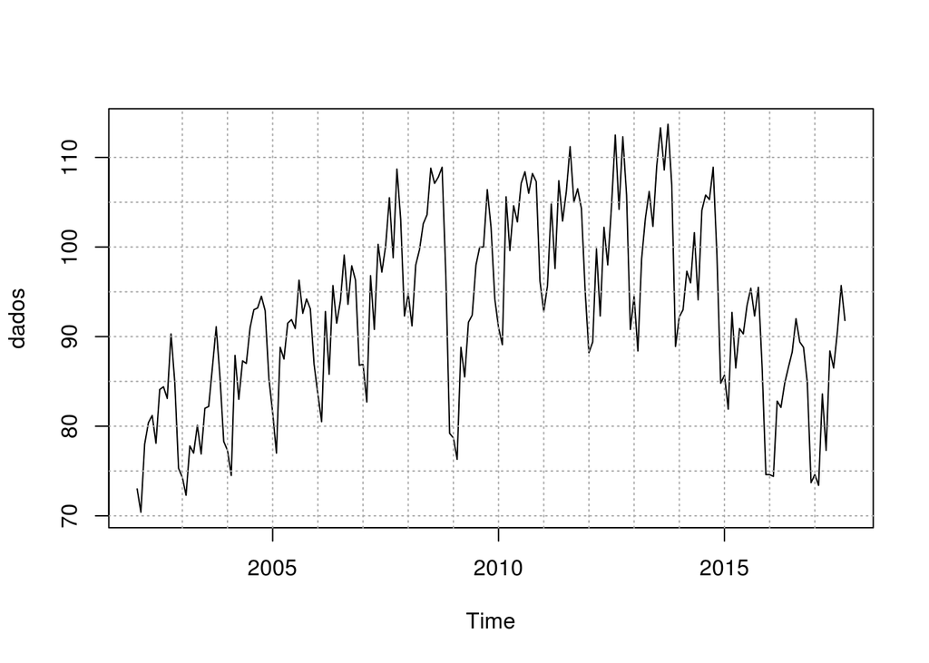

```r
plot(dados)
abline(h = seq(70,110,5), v = seq(2003,2017,1), lty = 3, col = "darkgrey")
```

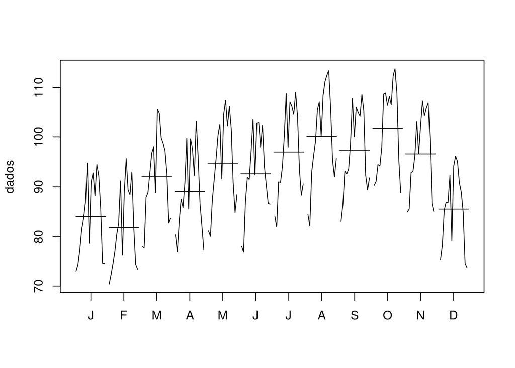

```r
monthplot(dados)
```

Percebe-se que a série tem um média maior em outubro podemos justificar pelo aquecimento do mercado devido às comemorações de final de ano.

### Modelagem

#### Segundo Box & Jenkins

A metodologia de Box & Jenkins para séries temporais estacionárias e construção de modelos ARIMA segue um ciclo iterativo composto por cinco etapas:

- Especificação: classe geral de estruturas `SARIMA(p,d,q)(P,D,Q)` é analisada
- Identificação: com base na `FAC` e `FACP` amostrais e outros critérios

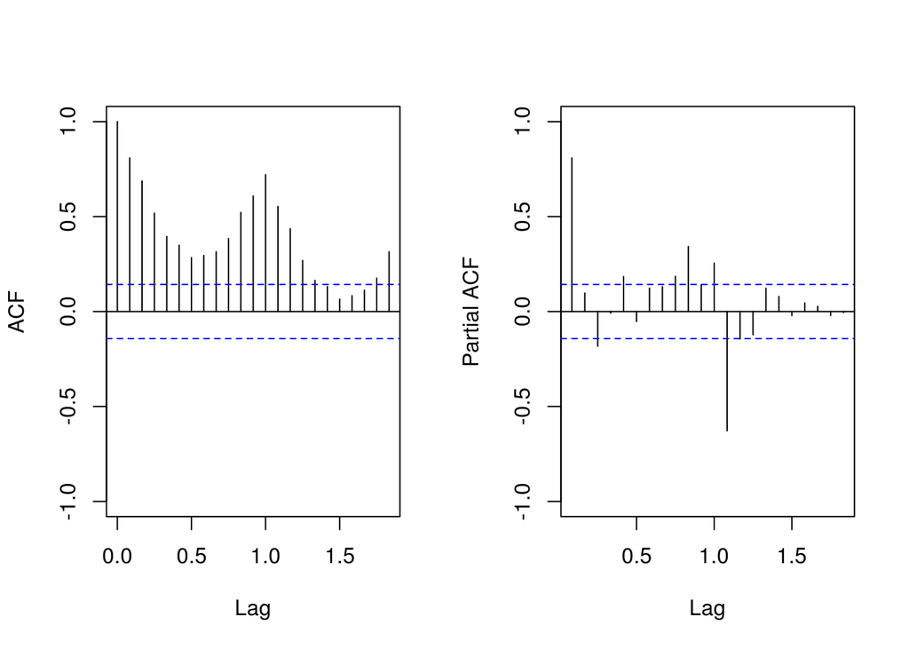

```r
# autocorrelacao e autorrelacao parcial
x=acf(dados,plot=F)
par(mfrow=c(1,2))
plot(x,ylim=c(-1,1), main="")
pacf(dados, main="",ylim=c(-1,1))
```

```r
#analisando a autocorrelacao extendida
require(TSA)
eacf(dados, ar.max = 7, ma.max = 13)
```

```
## AR/MA
##   0 1 2 3 4 5 6 7 8 9 10 11 12 13
## 0 x x x x x x x x x x x  x  x  x
## 1 o x o x o x o o o x o  x  o  x
## 2 x x o x o x o o o o o  x  x  x
## 3 o x o x o o o o o o o  x  o  x
## 4 o x o x o o o o o o o  x  o  x
## 5 x x x o o o o o o o o  x  x  o
## 6 x x o o o o o o o o o  x  x  o
## 7 x o o o o o o o o o o  x  x  x
```

```r
#testando a estacionariedade
#com o teste de Dickey-Fuller
adf.test(dados)
```

```
##
##  Augmented Dickey-Fuller Test
##
## data:  dados
## Dickey-Fuller = -3.5435, Lag order = 5, p-value = 0.04019
## alternative hypothesis: stationary
```

```r
require(forecast)
modelo = auto.arima(dados)
modelo
```

```
## Series: dados
## ARIMA(2,1,2)(1,1,2)[12]
##
## Coefficients:
##           ar1      ar2     ma1     ma2     sar1     sma1     sma2
##       -1.0337  -0.8394  0.7152  0.5751  -0.6106  -0.1326  -0.6222
## s.e.   0.0767   0.0848  0.1286  0.1291   0.2687   0.2534   0.1956
##
## sigma^2 estimated as 7.428:  log likelihood=-430.24
## AIC=876.48   AICc=877.34   BIC=901.84
```

Identificado o modelo `ARIMA(2,1,2)(1,1,2)` podemos verificar de forma rápida, se os parametros do modelo são significativos.

```r
BETS.t_test(modelo)
```

```
##          Coeffs Std.Errors          t Crit.Values Rej.H0
## ar1  -1.0337063 0.07666982 13.4825722    1.973231   TRUE
## ar2  -0.8393757 0.08477005  9.9017951    1.973231   TRUE
## ma1   0.7152279 0.12863922  5.5599520    1.973231   TRUE
## ma2   0.5751166 0.12908716  4.4552577    1.973231   TRUE
## sar1 -0.6105807 0.26871234  2.2722468    1.973231   TRUE
## sma1 -0.1326116 0.25344085  0.5232448    1.973231  FALSE
## sma2 -0.6222140 0.19563715  3.1804492    1.973231   TRUE
```

Podemos ver que o parametro da parte de médias móveis `sm1` não é significativo e deve ser retirado do modelo.

```r
modelo$coef = modelo$coef[-length(modelo$coef)]
```

```r
fit.pim = Arima(dados,order=c(2,1,2),seasonal = c(1,1,0),method = "ML",lambda = 0)
summary(fit.pim)
```

```
## Series: dados
## ARIMA(2,1,2)(1,1,0)[12]
## Box Cox transformation: lambda= 0
##
## Coefficients:
##           ar1      ar2     ma1     ma2     sar1
##       -1.0129  -0.7913  0.6503  0.5031  -0.4264
## s.e.   0.0944   0.0848  0.1329  0.1139   0.0713
##
## sigma^2 estimated as 0.001156:  log likelihood=346.57
## AIC=-681.15   AICc=-680.65   BIC=-662.12
##
## Training set error measures:
##                       ME     RMSE      MAE         MPE     MAPE      MASE
## Training set -0.04136502 3.030084 2.274723 -0.06599341 2.429589 0.4423975
##                     ACF1
## Training set -0.01146695
```

- Estimação: os parâmetros do modelo identificado são estimados e testados estatísticamente sobre uma significancia
- Diagnótico
- Modelo definitivo

### Testando estacionariedade